# 1. Title : Natural Language Processing with Disaster Tweets

Twitter has become an important communication channel in times of emergency. The ubiquitousness of smartphones enables people to announce an emergency they’re observing in real-time. Because of this, more agencies are interested in programatically monitoring Twitter (i.e. disaster relief organizations and news agencies).

But, it’s not always clear whether a person’s words are actually announcing a disaster.

In this competition, you’re challenged to build a machine learning model that predicts which Tweets are about real disasters and which one’s aren’t. You’ll have access to a dataset of 10,000 tweets that were hand classified. If this is your first time working on an NLP problem, we've created a quick tutorial to get you up and running.

# 2. Importing required Libraries

```python
import re
import numpy as np
import pandas as pd
from tqdm import tqdm
import matplotlib.pyplot as plt
import seaborn as sns
import nltk
from nltk.corpus import stopwords

import warnings
warnings.filterwarnings('ignore')

import keras
from keras.initializers import Constant
import tensorflow as tf
from tensorflow.keras.preprocessing.text import Tokenizer
from tensorflow.keras.preprocessing.sequence import pad_sequences
from tensorflow.keras import layers, Sequential
from tensorflow.keras import optimizers
from tensorflow.keras.optimizers import RMSprop
from tensorflow.keras.layers import LSTM
```

# 3. Loading the data

```python
train_data = pd.read_csv('input/train.csv', dtype={'id': np.int16, 'target': np.int16})
test_data = pd.read_csv('input/test.csv', dtype={'id': np.int16})
```

# 4. EDA

**1) Check missing values**

```python
train_data.isnull().sum()
```

```
id             0
keyword       61
location    2533
text           0
target         0
dtype: int64
```

Missing values exist in the keyword, location variables.

[figure not shown]

```python
miss_cols = ['keyword', 'location']

fig, axes = plt.subplots(2,figsize=(10, 15))

sns.barplot(x=train_data[miss_cols].isnull().sum().index, y=train_data[miss_cols].isnull().sum().values, ax=axes[0])
sns.barplot(x=train_data[miss_cols].isnull().sum().index, y=train_data[miss_cols].isnull().sum().values, ax=axes[1])

axes[0].set_ylabel('Missing Count', size=15, labelpad=20)
axes[0].tick_params(axis='x', labelsize=15)
axes[0].tick_params(axis='y', labelsize=15)
axes[1].set_ylabel('Missing Count', size=15, labelpad=20)
axes[1].tick_params(axis='x', labelsize=15)
axes[1].tick_params(axis='y', labelsize=15)

axes[0].set_title('Train data', fontsize=15)
axes[1].set_title('Test data', fontsize=15)

plt.show()
```

LOCATION variable has many missing values.

```python
train_data.groupby('target').count()['id']
```

```
target
0    4342
1    3271
Name: id, dtype: int64
```

There are more tweets with class 0 ( No disaster) than class 1 ( disaster tweets)

```python
train_x = train_data['text'].copy()
train_y = train_data['target'].copy()
```

0 is more than 1, but it is not much different.

**2) Data Cleaning**

Missing values must be processed before data analysis can be performed.

```python
stop = stopwords.words('english')
def clean(text):

    text = re.sub(r'http\S+', ' ', text)

    text = re.sub(r'<.*?>', ' ', text)

    text = re.sub(r'#\w+', ' ', text)

    text = re.sub(r'@\w+', ' ', text)

    text = re.sub(r'\d+', ' ', text)

    text = text.split()

    text = ' '.join([word for word in text if word not in stop])

    return text
```

Removing Stop words

```python
train_x_cleaned = train_x.apply(clean)
train_x_cleaned.head()
```

```
0                Our Deeds Reason May ALLAH Forgive us
1               Forest fire near La Ronge Sask. Canada
2    All residents asked 'shelter place' notified o...
3        , people receive evacuation orders California
4          Just got sent photo Ruby smoke pours school
Name: text, dtype: object
```

Max Length

```python
max_len = max(train_x_cleaned.apply(len))
print('max length: {}'.format(max_len))
```

```
max length: 141
```

**3) Tokenize**

the text must be vectorized by generating a sequence of specified lengths for each tweet in the dataset. Using the Keras Tokenizer

```python
tokenizer = Tokenizer()
tokenizer.fit_on_texts(train_x_cleaned)
vocab_size = len(tokenizer.word_index) + 1
x = tokenizer.texts_to_sequences(train_x_cleaned)
x = pad_sequences(x, max_len, padding='post')
y = train_y
print('train_x_clean:', train_x_cleaned[4])
print('*'*50)
print('x:',x[5])
print('vocabulary size:{}'.format(vocab_size))
```

```
train_x_clean: Just got sent photo Ruby smoke pours school
x: [ 318   45 1367  772 6083  478 1112  319    6    0    0    0    0    0
    0    0    0    0    0    0    0    0    0    0    0    0    0    0
    0    0    0    0    0    0    0    0    0    0    0    0    0    0
    0    0    0    0    0    0    0    0    0    0    0    0    0    0
    0    0    0    0    0    0    0    0    0    0    0    0    0    0
    0    0    0    0    0    0    0    0    0    0    0    0    0    0
    0    0    0    0    0    0    0    0    0    0    0    0    0    0
    0    0    0    0    0    0    0    0    0    0    0    0    0    0
    0    0    0    0    0    0    0    0    0    0    0    0    0    0
    0    0    0    0    0    0    0    0    0    0    0    0    0    0
    0]
vocabulary size:13947
```

```python
x.shape
```

```
(7613, 141)
```

```python
y.shape
```

```
(7613,)
```

# 5. Create Models

**model 1**

GRU implementation with basic embedding layer

```python
epoch_size =10
batch_size = 32
embedding_dim = 16
optimizer = optimizers.Adam(lr=3e-4)

model = Sequential([
    layers.Embedding(vocab_size, embedding_dim, input_length=max_len),
    layers.Bidirectional(layers.GRU(256, return_sequences=True)),
    layers.GlobalMaxPool1D(),
#     layers.Dense(128, activation='relu'),
#     layers.Dropout(0.4),
    layers.Dense(64, activation='relu'),
    layers.Dropout(0.4),
    layers.Dense(2, activation='sigmoid')
])
model.summary()
```

```
Model: "sequential"
_________________________________________________________________
Layer (type)                 Output Shape              Param #
=================================================================
embedding (Embedding)        (None, 141, 16)           223152
_________________________________________________________________
bidirectional (Bidirectional (None, 141, 512)          420864
_________________________________________________________________
global_max_pooling1d (Global (None, 512)               0
_________________________________________________________________
dense (Dense)                (None, 64)                32832
_________________________________________________________________
dropout (Dropout)            (None, 64)                0
_________________________________________________________________
dense_1 (Dense)              (None, 2)                 130
=================================================================
Total params: 676,978
Trainable params: 676,978
Non-trainable params: 0
_________________________________________________________________
```

training the model

```python
model.compile(loss='sparse_categorical_crossentropy', optimizer = 'adam', metrics=['accuracy'])
history = model.fit(x, y, epochs=epoch_size, validation_split=0.1)
```

```python
test_x = test_data['text'].copy()
test_x = test_x.apply(clean)
test_x = tokenizer.texts_to_sequences(test_x)
test_x = pad_sequences(test_x, max_len, padding='post')
```

prediction

```python
test_pred = np.argmax(model.predict(test_x), axis=1)
print(test_pred)
```

```
[1 0 1 ... 1 1 1]
```

Check the loss ans accuracy

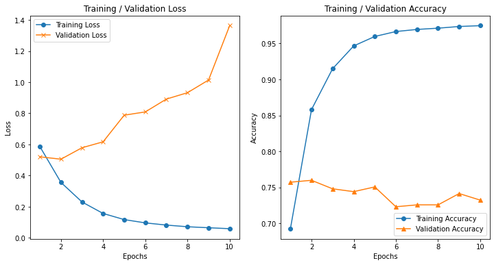

```python
history1 = history.history

trg_loss = history1['loss']
val_loss = history1['val_loss']

trg_acc = history1['accuracy']
val_acc = history1['val_accuracy']

epochs = range(1, len(trg_acc) + 1)

# plot losses and accuracies for training and validation
fig = plt.figure(figsize=(12,6))
ax = fig.add_subplot(1, 2, 1)
plt.plot(epochs, trg_loss, marker='o', label='Training Loss')
plt.plot(epochs, val_loss, marker='x', label='Validation Loss')
plt.title("Training / Validation Loss")
ax.set_ylabel("Loss")
ax.set_xlabel("Epochs")
plt.legend(loc='best')

ax = fig.add_subplot(1, 2, 2)
plt.plot(epochs, trg_acc, marker='o', label='Training Accuracy')
plt.plot(epochs, val_acc, marker='^', label='Validation Accuracy')
plt.title("Training / Validation Accuracy")
ax.set_ylabel("Accuracy")
ax.set_xlabel("Epochs")
plt.legend(loc='best')
plt.show()
```

In train data, it is a desirable state in which the loss is small and the accuracy value is high. However, in validation data, it is not convergent and the value is not good.

**model 2**

```python
epoch_size =10
batch_size = 32
embedding_dim = 16
optimizer = optimizers.Adam(lr=3e-4)

model2 = Sequential([
    layers.Embedding(vocab_size, embedding_dim, input_length=max_len),
    layers.Bidirectional(layers.GRU(256, return_sequences=True)),
    layers.GlobalMaxPool1D(),
    layers.Dense(64, activation='relu'),
    layers.Dropout(0.4),
    layers.Dense(2, activation='sigmoid')
])
model2.summary()
```

```
Model: "sequential_1"
_________________________________________________________________
Layer (type)                 Output Shape              Param #
=================================================================
embedding_1 (Embedding)      (None, 141, 16)           223152
_________________________________________________________________
bidirectional_1 (Bidirection (None, 141, 512)          420864
_________________________________________________________________
global_max_pooling1d_1 (Glob (None, 512)               0
_________________________________________________________________
dense_2 (Dense)              (None, 64)                32832
_________________________________________________________________
dropout_1 (Dropout)          (None, 64)                0
_________________________________________________________________
dense_3 (Dense)              (None, 2)                 130
=================================================================
Total params: 676,978
Trainable params: 676,978
Non-trainable params: 0
_________________________________________________________________
```

```python
model2.compile(loss='sparse_categorical_crossentropy', optimizer = 'adam', metrics=['accuracy'])
history = model2.fit(x, y, epochs=epoch_size, validation_split=0.1)
```

```python
test_pred = np.argmax(model2.predict(test_x), axis=1)
print(test_pred)
```

```
[1 0 1 ... 1 1 1]
```

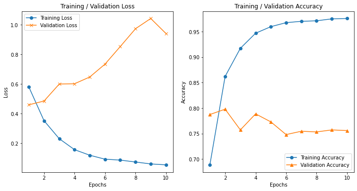

```python
history2 = history.history

trg_loss = history2['loss']
val_loss = history2['val_loss']

trg_acc = history2['accuracy']
val_acc = history2['val_accuracy']

epochs = range(1, len(trg_acc) + 1)

# plot losses and accuracies for training and validation
fig = plt.figure(figsize=(12,6))
ax = fig.add_subplot(1, 2, 1)
plt.plot(epochs, trg_loss, marker='o', label='Training Loss')
plt.plot(epochs, val_loss, marker='x', label='Validation Loss')
plt.title("Training / Validation Loss")
ax.set_ylabel("Loss")
ax.set_xlabel("Epochs")
plt.legend(loc='best')

ax = fig.add_subplot(1, 2, 2)
plt.plot(epochs, trg_acc, marker='o', label='Training Accuracy')
plt.plot(epochs, val_acc, marker='^', label='Validation Accuracy')
plt.title("Training / Validation Accuracy")
ax.set_ylabel("Accuracy")
ax.set_xlabel("Epochs")
plt.legend(loc='best')
plt.show()
```

It is improved over model 1, but it is still not convergent and has a good value in validation data.

**model 3**

LSTM implementation with basic embedding layer

```python
epoch_size =10
batch_size = 32
embedding_dim = 16
optimizer = optimizers.Adam(lr=3e-4)

model3 = Sequential([
    layers.Embedding(vocab_size, embedding_dim, input_length=max_len, trainable=False),
    layers.SpatialDropout1D(0.2),

    layers.Bidirectional(layers.LSTM(64, recurrent_dropout=0.5, dropout=0.5, return_sequences=True)),
    layers.Bidirectional(layers.LSTM(64, recurrent_dropout=0.5, dropout=0.5)),

    layers.Dense(64, activation='relu'),
    layers.Dense(2, activation='sigmoid')
])
model3.summary()
```

```
Model: "sequential_2"
_________________________________________________________________
Layer (type)                 Output Shape              Param #
=================================================================
embedding_2 (Embedding)      (None, 141, 16)           223152
_________________________________________________________________
spatial_dropout1d (SpatialDr (None, 141, 16)           0
_________________________________________________________________
bidirectional_2 (Bidirection (None, 141, 128)          41472
_________________________________________________________________
bidirectional_3 (Bidirection (None, 128)               98816
_________________________________________________________________
dense_4 (Dense)              (None, 64)                8256
_________________________________________________________________
dense_5 (Dense)              (None, 2)                 130
=================================================================
Total params: 371,826
Trainable params: 148,674
Non-trainable params: 223,152
_________________________________________________________________
```

```python
model3.compile(loss='sparse_categorical_crossentropy', optimizer = optimizer, metrics=['accuracy'])
history = model3.fit(x, y, epochs=epoch_size, validation_split=0.1)
```

```python
test_pred = np.argmax(model3.predict(test_x), axis=1)
print(test_pred)
```

```
[0 0 0 ... 0 0 0]
```

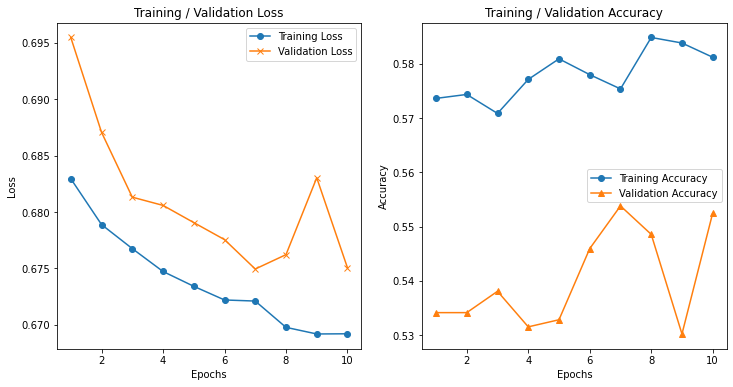

```python
history3 = history.history

trg_loss = history3['loss']
val_loss = history3['val_loss']

trg_acc = history3['accuracy']
val_acc = history3['val_accuracy']

epochs = range(1, len(trg_acc) + 1)

# plot losses and accuracies for training and validation
fig = plt.figure(figsize=(12,6))
ax = fig.add_subplot(1, 2, 1)
plt.plot(epochs, trg_loss, marker='o', label='Training Loss')
plt.plot(epochs, val_loss, marker='x', label='Validation Loss')
plt.title("Training / Validation Loss")
ax.set_ylabel("Loss")
ax.set_xlabel("Epochs")
plt.legend(loc='best')

ax = fig.add_subplot(1, 2, 2)
plt.plot(epochs, trg_acc, marker='o', label='Training Accuracy')
plt.plot(epochs, val_acc, marker='^', label='Validation Accuracy')
plt.title("Training / Validation Accuracy")
ax.set_ylabel("Accuracy")
ax.set_xlabel("Epochs")
plt.legend(loc='best')
plt.show()
```

**model 4**

GRU implementation with basic embedding layer and 3 Dense layers

```python
epoch_size =10
batch_size = 32
embedding_dim = 16
optimizer = optimizers.Adam(lr=3e-4)

model4 = Sequential([
    layers.Embedding(vocab_size, embedding_dim, input_length=max_len),
    layers.Bidirectional(layers.GRU(256, return_sequences=True)),
    layers.GlobalMaxPool1D(),
    layers.Dense(128, activation='relu'),
    layers.Dropout(0.4),
    layers.Dense(64, activation='relu'),
    layers.Dropout(0.4),
    layers.Dense(2, activation='sigmoid')
])
model4.summary()
```

```
Model: "sequential_3"
_________________________________________________________________
Layer (type)                 Output Shape              Param #
=================================================================
embedding_3 (Embedding)      (None, 141, 16)           223152
_________________________________________________________________
bidirectional_4 (Bidirection (None, 141, 512)          420864
_________________________________________________________________
global_max_pooling1d_2 (Glob (None, 512)               0
_________________________________________________________________
dense_6 (Dense)              (None, 128)               65664
_________________________________________________________________
dropout_2 (Dropout)          (None, 128)               0
_________________________________________________________________
dense_7 (Dense)              (None, 64)                8256
_________________________________________________________________
dropout_3 (Dropout)          (None, 64)                0
_________________________________________________________________
dense_8 (Dense)              (None, 2)                 130
=================================================================
Total params: 718,066
Trainable params: 718,066
Non-trainable params: 0
_________________________________________________________________
```

```python
model4.compile(loss='sparse_categorical_crossentropy', optimizer = optimizer, metrics=['accuracy'])
history = model4.fit(x, y, epochs=epoch_size, validation_split=0.2)
```

```python
test_pred = np.argmax(model2.predict(test_x), axis=1)
print(test_pred)
```

```
[1 0 1 ... 1 1 1]
```

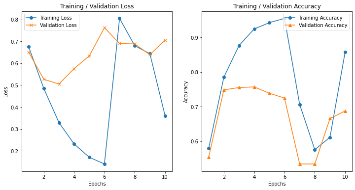

```python
history4 = history.history

trg_loss = history4['loss']
val_loss = history4['val_loss']

trg_acc = history4['accuracy']
val_acc = history4['val_accuracy']

epochs = range(1, len(trg_acc) + 1)

# plot losses and accuracies for training and validation
fig = plt.figure(figsize=(12,6))
ax = fig.add_subplot(1, 2, 1)
plt.plot(epochs, trg_loss, marker='o', label='Training Loss')
plt.plot(epochs, val_loss, marker='x', label='Validation Loss')
plt.title("Training / Validation Loss")
ax.set_ylabel("Loss")
ax.set_xlabel("Epochs")
plt.legend(loc='best')

ax = fig.add_subplot(1, 2, 2)
plt.plot(epochs, trg_acc, marker='o', label='Training Accuracy')
plt.plot(epochs, val_acc, marker='^', label='Validation Accuracy')
plt.title("Training / Validation Accuracy")
ax.set_ylabel("Accuracy")
ax.set_xlabel("Epochs")
plt.legend(loc='best')
plt.show()
```

The loss value is high and the accuracy is significantly different from the train result.

**model 5**

GloVe embedded LSTM, RNN and add BatchNormalization

```python
embeddings_dictionary = dict()
embedding_dim = 100
glove_file = open('glove.6B/glove.6B.100d.txt', encoding='UTF8')
for line in glove_file:
    records = line.split()
    word = records[0]
    vector_dimensions = np.asarray(records[1:], dtype='float32')
    embeddings_dictionary [word] = vector_dimensions
glove_file.close()
```

```python
embedding_matrix = np.zeros((vocab_size, embedding_dim))
for word, index in tokenizer.word_index.items():
    embedding_vector = embeddings_dictionary.get(word)
    if embedding_vector is not None:
        embedding_matrix[index] = embedding_vector
```

```python
epoch_size =10
batch_size = 32

model5 = Sequential([
    layers.Embedding(input_dim=embedding_matrix.shape[0],
                        output_dim=embedding_matrix.shape[1],
                        weights = [embedding_matrix]
                        ),
    layers.Bidirectional(LSTM(64, return_sequences = True, recurrent_dropout=0.2)),
    layers.GlobalMaxPool1D(),
    layers.BatchNormalization(),
    layers.Dropout(0.5),
    layers.Dense(128, activation='relu'),
    layers.Dropout(0.5),
    layers.Dense(64, activation='relu'),
    layers.Dropout(0.5),
    layers.Dense(1, activation='sigmoid')
])
model5.summary()
```

```
Model: "sequential_4"
_________________________________________________________________
Layer (type)                 Output Shape              Param #
=================================================================
embedding_4 (Embedding)      (None, None, 100)         1394700
_________________________________________________________________
bidirectional_5 (Bidirection (None, None, 128)         84480
_________________________________________________________________
global_max_pooling1d_3 (Glob (None, 128)               0
_________________________________________________________________
batch_normalization (BatchNo (None, 128)               512
_________________________________________________________________
dropout_4 (Dropout)          (None, 128)               0
_________________________________________________________________
dense_9 (Dense)              (None, 128)               16512
_________________________________________________________________
dropout_5 (Dropout)          (None, 128)               0
_________________________________________________________________
dense_10 (Dense)             (None, 64)                8256
_________________________________________________________________
dropout_6 (Dropout)          (None, 64)                0
_________________________________________________________________
dense_11 (Dense)             (None, 1)                 65
=================================================================
Total params: 1,504,525
Trainable params: 1,504,269
Non-trainable params: 256
_________________________________________________________________
```

```python
model5.compile(loss='binary_crossentropy', optimizer = RMSprop(learning_rate=0.0001), metrics=['accuracy'])
history5 = model5.fit(x, y, epochs=epoch_size, validation_split=0.2)
```

```python
test_pred = np.argmax(model5.predict(test_x), axis=1)
print(test_pred)
```

```
[0 0 0 ... 0 0 0]
```

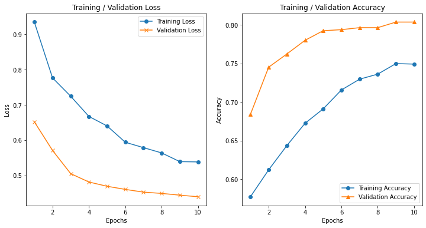

```python
history = history5.history

trg_loss = history['loss']
val_loss = history['val_loss']

trg_acc = history['accuracy']
val_acc = history['val_accuracy']

epochs = range(1, len(trg_acc) + 1)

# plot losses and accuracies for training and validation
fig = plt.figure(figsize=(12,6))
ax = fig.add_subplot(1, 2, 1)
plt.plot(epochs, trg_loss, marker='o', label='Training Loss')
plt.plot(epochs, val_loss, marker='x', label='Validation Loss')
plt.title("Training / Validation Loss")
ax.set_ylabel("Loss")
ax.set_xlabel("Epochs")
plt.legend(loc='best')

ax = fig.add_subplot(1, 2, 2)
plt.plot(epochs, trg_acc, marker='o', label='Training Accuracy')
plt.plot(epochs, val_acc, marker='^', label='Validation Accuracy')
plt.title("Training / Validation Accuracy")
ax.set_ylabel("Accuracy")
ax.set_xlabel("Epochs")
plt.legend(loc='best')
plt.show()
```

Both loss and accuracy values converge and the difference from the train data results tends to decrease. However, the loss value is still large and the accumulation value seems to need further improvement.

**model 6**

GloVe embedded GRU

```python
epoch_size =10
batch_size = 32

model6 = Sequential([
    layers.Embedding(input_dim=embedding_matrix.shape[0],
                        output_dim=embedding_matrix.shape[1],
                        weights = [embedding_matrix]
                        ),
    layers.Bidirectional(layers.GRU(256, return_sequences=True)),
    layers.GlobalMaxPool1D(),
    layers.Dense(64, activation='relu'),
    layers.Dropout(0.4),
    layers.Dense(2, activation='sigmoid')
])
model6.summary()
```

```
Model: "sequential_5"
_________________________________________________________________
Layer (type)                 Output Shape              Param #
=================================================================
embedding_5 (Embedding)      (None, None, 100)         1394700
_________________________________________________________________
bidirectional_6 (Bidirection (None, None, 512)         549888
_________________________________________________________________
global_max_pooling1d_4 (Glob (None, 512)               0
_________________________________________________________________
dense_12 (Dense)             (None, 64)                32832
_________________________________________________________________
dropout_7 (Dropout)          (None, 64)                0
_________________________________________________________________
dense_13 (Dense)             (None, 2)                 130
=================================================================
Total params: 1,977,550
Trainable params: 1,977,550
Non-trainable params: 0
_________________________________________________________________
```

```python
model6.compile(loss='sparse_categorical_crossentropy', optimizer = RMSprop(learning_rate=0.0001), metrics=['accuracy'])
history6 = model6.fit(x, y, epochs=epoch_size, validation_split=0.1)
```

```python
test_pred = np.argmax(model6.predict(test_x), axis=1)
print(test_pred)
```

```
[1 0 1 ... 1 1 0]
```

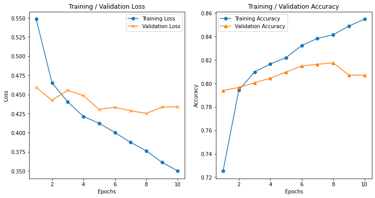

```python
history = history6.history

trg_loss = history['loss']
val_loss = history['val_loss']

trg_acc = history['accuracy']
val_acc = history['val_accuracy']

epochs = range(1, len(trg_acc) + 1)

# plot losses and accuracies for training and validation
fig = plt.figure(figsize=(12,6))
ax = fig.add_subplot(1, 2, 1)
plt.plot(epochs, trg_loss, marker='o', label='Training Loss')
plt.plot(epochs, val_loss, marker='x', label='Validation Loss')
plt.title("Training / Validation Loss")
ax.set_ylabel("Loss")
ax.set_xlabel("Epochs")
plt.legend(loc='best')

ax = fig.add_subplot(1, 2, 2)
plt.plot(epochs, trg_acc, marker='o', label='Training Accuracy')
plt.plot(epochs, val_acc, marker='^', label='Validation Accuracy')
plt.title("Training / Validation Accuracy")
ax.set_ylabel("Accuracy")
ax.set_xlabel("Epochs")
plt.legend(loc='best')
plt.show()
```

Both loss and accuracy values were improved in the desired direction.

# 6. Create a submission

Generate the results as a csv file.

```python
submission = pd.DataFrame({'id':test_data['id'], 'target':test_pred})
submission.to_csv('submission.csv', index=False)
```